# Analysis of s-alinines run during calibration of 2026 seal std

Peter Ditchfield

2026-03-26

#### Data used for the analyses

The data file used is

Salanine-for-R.csv”

This file is included in the folder with this r_markdown document but path names may change so beware.

It may be useful to have both the Name and Run columns as factors so they can be used for plotting

#### Figure 1a a basic cross plot

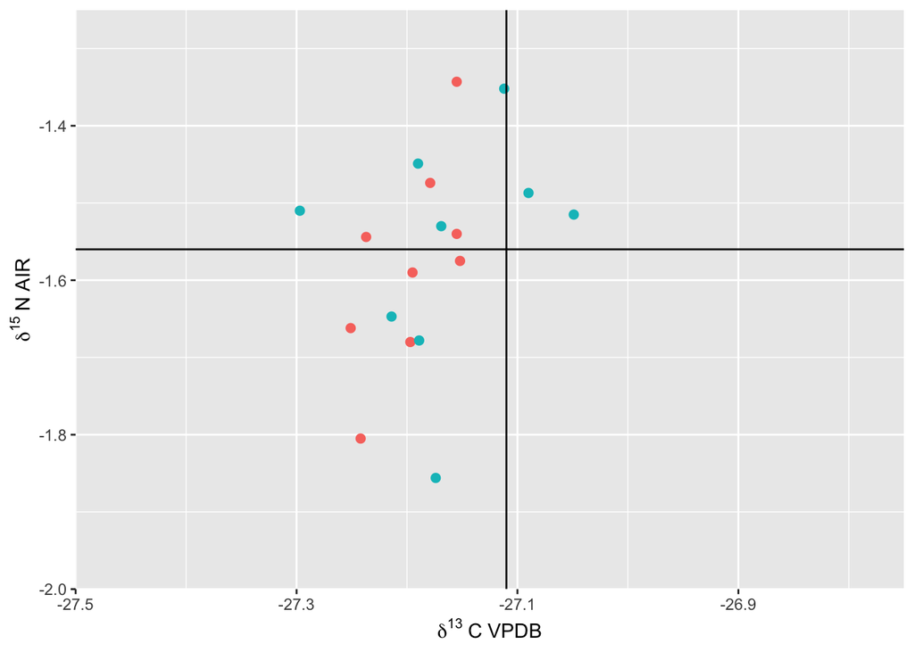

That is not great, the data looks to be systematically off from the ‘certified’ mean by about -0.1 per mil for carbon.

#### Calculate some basic stats for the measured Alanine’s

Mean value for $\delta$ <sup>13</sup>C is -27.18 ‰ (VPDB) with a standard deviation of 0.0593 ‰. The excepted value based on multiple years checking against international standards is -27.11‰ (VPDB). So there is an offset of ca.-0.07‰.

Mean value for $\delta$ <sup>15</sup>N is -1.569 ‰ (AIR) with a standard deviation of 0.136 ‰. The excepted value based on multiple years checking against international standards is -1.56‰ (AIR).

Ah No ! The alanine values used for diet are the 2022 calibration values which are $\delta$ <sup>13</sup>C = -27.18 ‰ (VPDB) with a standard deviation of 0.01 and $\delta$ <sup>15</sup>N = -1.51 ‰ (AIR) with a standard deviation of 0.01

So re plot with these values

#### Figure 1b a basic cross plot

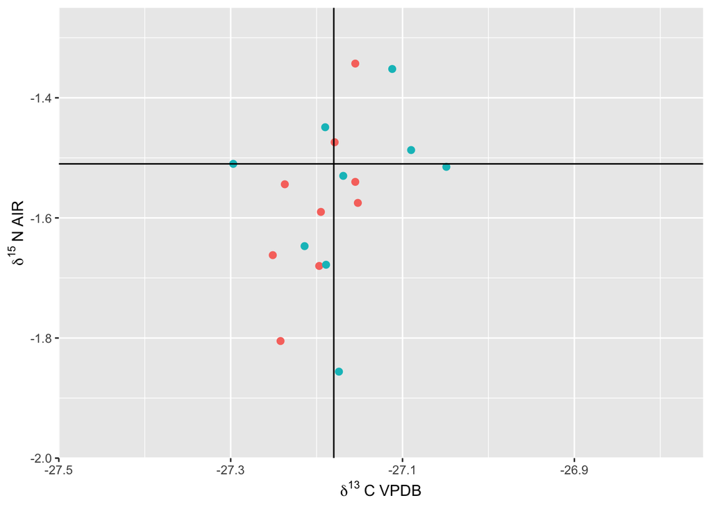

That looks much better although the $\delta$ <sup>15</sup>N values look a bit skewed towards more negative values.

#### Figure 2a KDE plot of salanine $\delta$ <sup>13</sup>C data

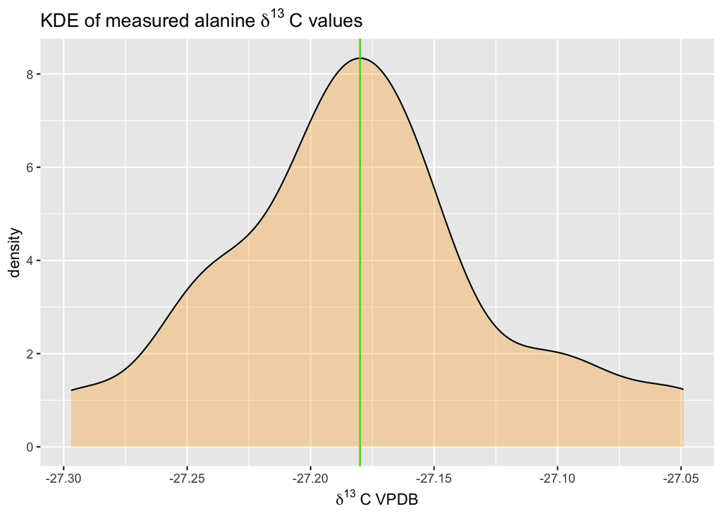

#### Figure 2b a qqplot of the $\delta$ <sup>13</sup>C data

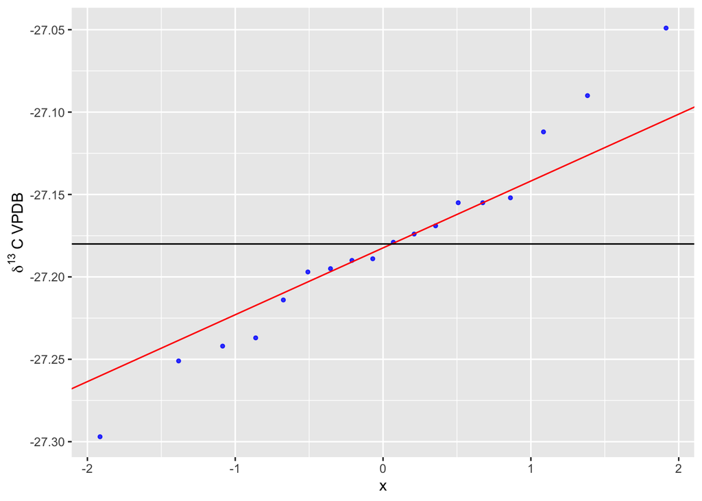

That looks as it should relatively normal with a mean at very close to -27.18.

#### Figure 3a KDE plot of salanine $\delta$ <sup>15</sup>N data

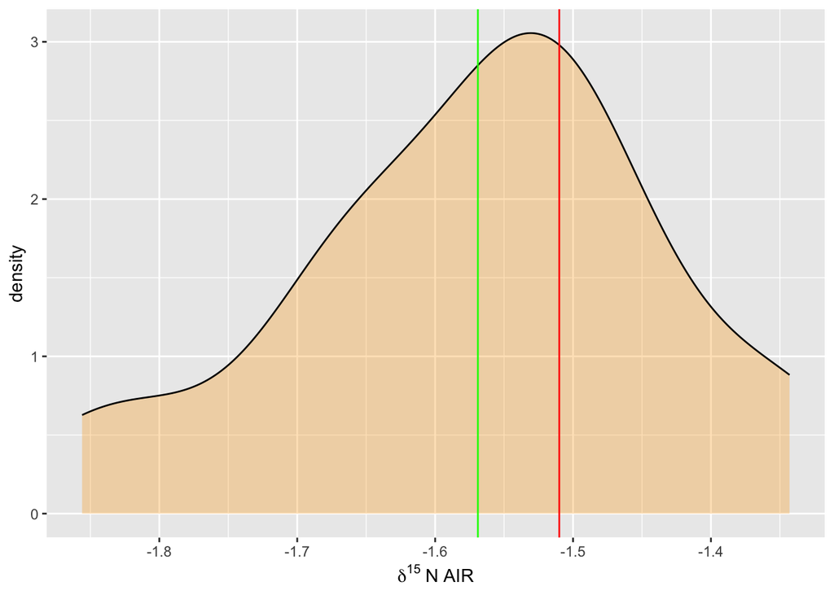

#### Figure 3b a qqplot of the $\delta$ <sup>15</sup>N data

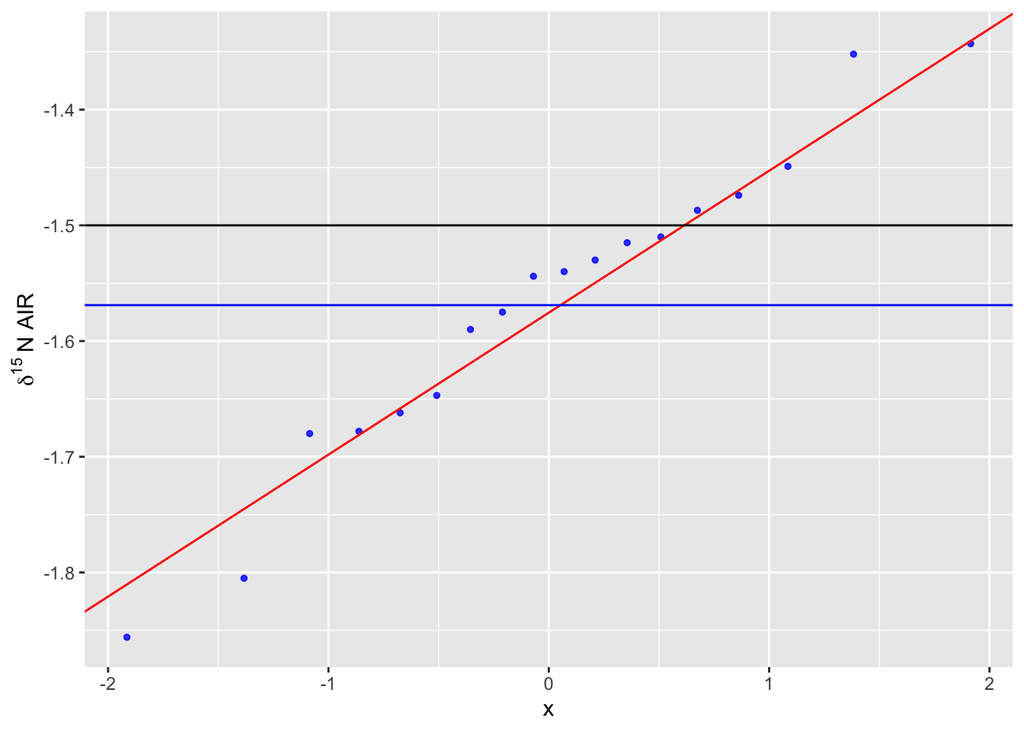

This looks OK but not as good as the carbon data, with not as good a fit to the line of normality and with a mean of -1.569 ‰ that is somewhat displaced from the set value for $\delta$ <sup>15</sup>N of -1.50 ‰.

### What about the other standards in these runs

Load other certified standards data file

It may be useful to have both the Name and Run columns as factors so they can be used for plotting

#### Basic cross plot

Note; only USGS40 and USGS88 have both carbon and nitrogen isotope data so these need to be separated out from the IAEA C6 for plotting. Note there are various data frames for various plots.

Now to make a cross plot  
please do not ignore my indents  
$\delta$ <sup>13</sup>C VS $\delta$ <sup>15</sup>N Cross Plot for USGS40 and USGS88 Measured Values

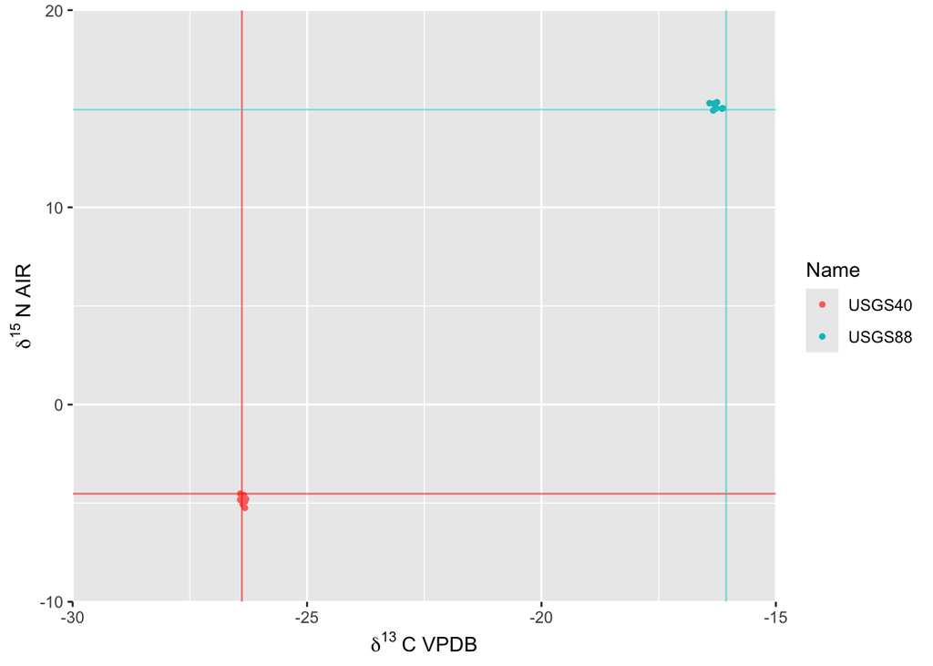

### calculate some basic stats for measured USGS 40

#### Figure 5a KDE plot of usgs40 $\delta$ <sup>13</sup>C data

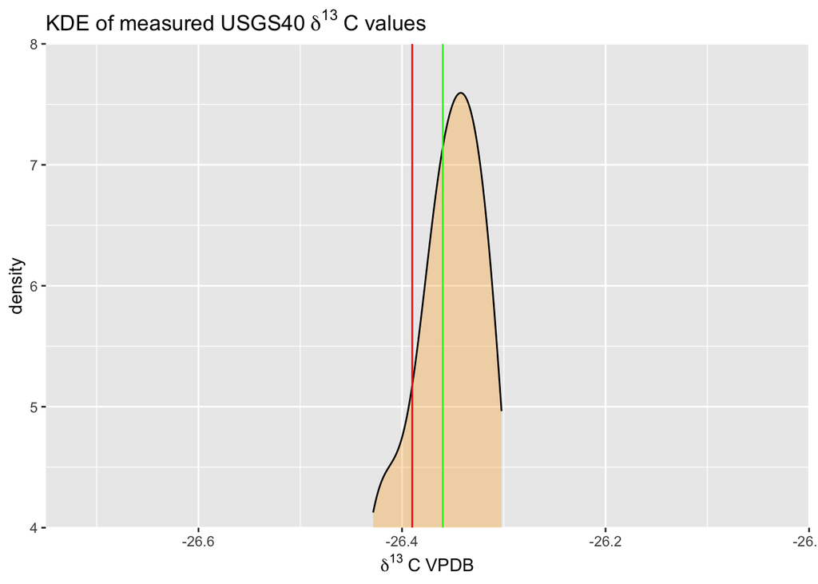

So the mean measured $\delta$ <sup>13</sup>C is very close ca. + 0.03‰ compared to the certified $\delta$ <sup>13</sup>C value for USGS40.

#### Figure 5b KDE plot of usgs40 $\delta$ <sup>15</sup>N data

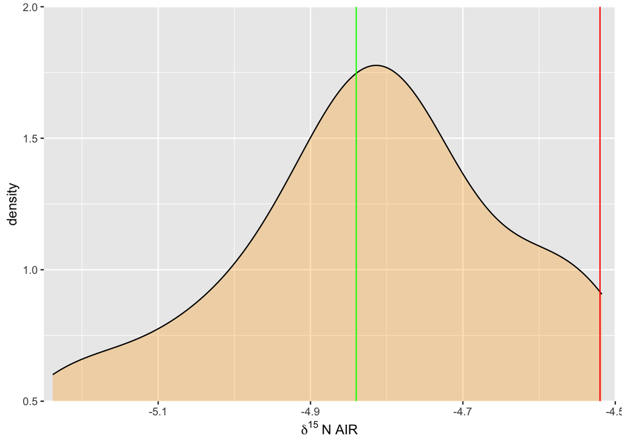

But the mean measured $\delta$ <sup>15</sup>N is ca. 0.32 ‰ too negative compared to the certified value that is quite a lot more of an off set than the $\delta$ <sup>13</sup>C data for USGS40.

### Calculate some basic stats for measured USGS 88

#### Figure 6a KDE plot of usgs88 $\delta$ <sup>13</sup>C data

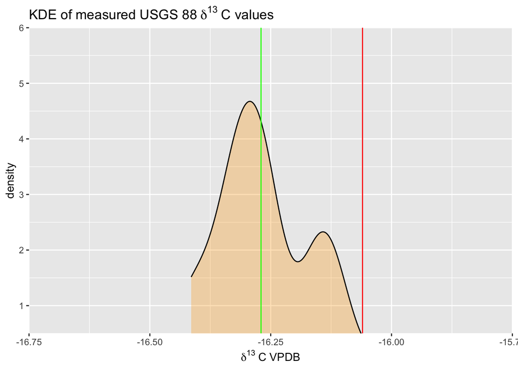

#### Figure 6b KDE plot of usgs88 $\delta$ <sup>15</sup>N data

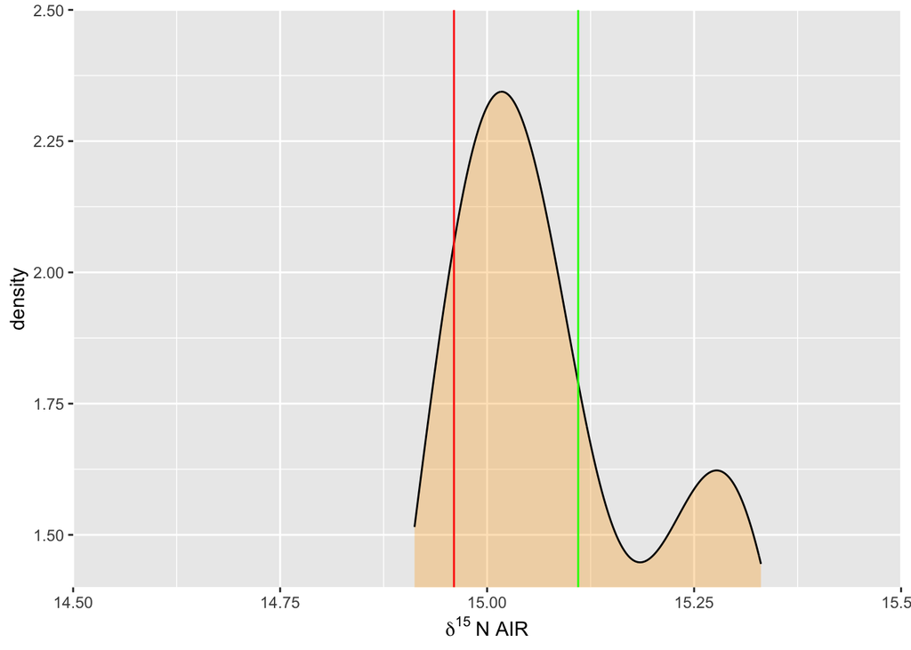

The mean measured $\delta$ <sup>15</sup>N for USGS88 is ca. 0.15 ‰ too positive compared to the certified value. However, given that the certified sd. is 0.14 and the measured sd. is 0.15 and that there is only 8 measured observations this is quite close.

### Calculate some basic stats for measured IAEA C6 $\delta$ <sup>13</sup>C data

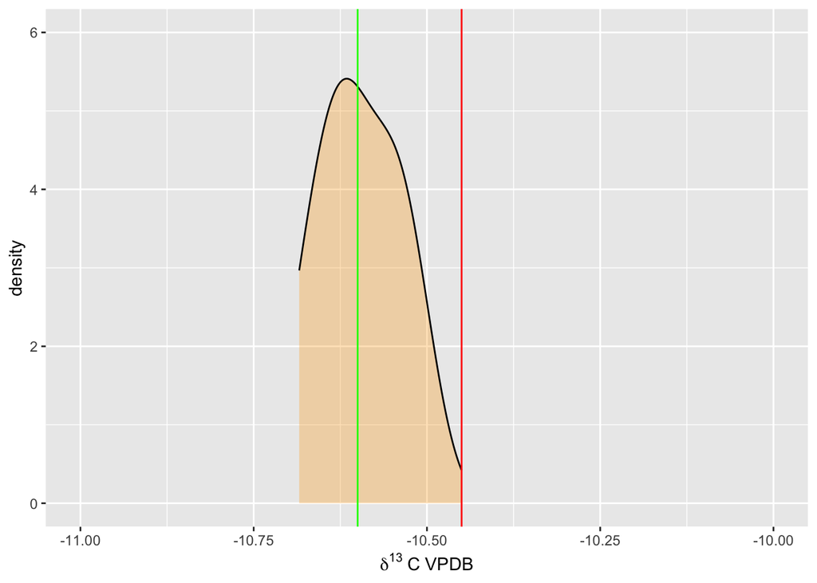

The mean measured $\delta$ <sup>13</sup>C of -10.6 is reasonably close to the certified mean of -10.45 compared to the certified $\delta$ <sup>13</sup>C value for IAEA-C6 of -10.45, this ca. - 0.15‰ difference or under measurement of <sup>13</sup>C maybe due to scale compression as this is ca. 16.7 ‰ away from the alanine working standard. However this value of -0.15‰ is less than the -0.21‰ value of the difference seen in the USGS88 data which is considerably closer to the the $\delta$ <sup>13</sup>C value of the alanine working standard.

#### Figure 8a plot of $\delta$ <sup>13</sup>C data for measured standards agains certified values

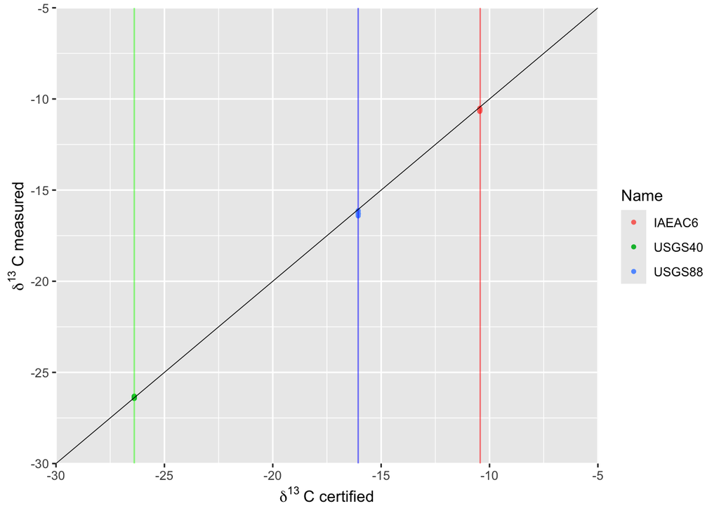

USGS40, which is very close to our alanine working standard sits on the 1:1 line. USGS88 and IAEAC6 which are further away from the working standard fall slightly below the 1:1 line and should be corrected for scale compression (under measurement).

so as a test apply the above correction to the measured standards.

For mean IAEAC6

```
## [1] -10.45
```

for USGS88mean

```
## [1] -16.1713
```

What is needed is an average value of offset normalised for the distance from the working standard.

For USGS88 the distance from the working standard is (-16.06) - (-27.18) = 11.12.

the offset is 0.21‰

so the value for each per mil difference is 0.21/11.12 = 0.01888

For IAEAC6 the distance from the working standard is (-10.45) - (-27.18) = 16.73

the offset is 0.15

so the value for each per mil difference is 0.15/16.73 = 0.00896

the average is (0.01888+0.00896)/2 = 0.01392